# Analysis of Time Series-An Introduction

```r
library(data.table)
library(here)
library(ggplot2)
library(grid)
library(gtable)
library(tseries)
library(RtsaPkg)
library(RplotterPkg)

current_dir <- here::here("Analysis of Time Series-An Introduction")
```

Author: Rick Dean

Article date: 2020-12-22

Abstract

The following notes/scripts/plots are inspired by the book [The Analysis of Time Series: An Introduction](http://www.ams.sunysb.edu/~xing/tsRbook/index.html) by Chris Chatfield and Haipeng Xing

# 2 Basic Descriptive Techniques

## 2.5 Series that contain a trend and no seasonal variation

### 2.5.2 Filtering

Task: Obtain the Beveridge wheat price data set and plot it. Note that the data set `bev` is a time series object of class “ts”.

```r
data(bev, package = "tseries") # set the data
str(bev)
```

```
##  Time-Series [1:370] from 1500 to 1869: 17 19 20 15 13 14 14 14 14 11 ...
```

Task: Plot the `bev` data set.

1. Convert the `bev` time series object (class = “ts”) to a data.frame using `RtsaPkg::ts_to_df()`:

```r
wheat_index_dt <- RtsaPkg::ts_to_df(bev, col_name = "PriceIdx")
str(wheat_index_dt)
```

```
## Classes 'data.table' and 'data.frame':   370 obs. of  2 variables:
##  $ PriceIdx: num  17 19 20 15 13 14 14 14 14 11 ...
##  $ DateTime: Date, format: "1500-01-01" "1501-01-01" ...
##  - attr(*, ".internal.selfref")=<externalptr>
```

2. Call `RplotterPkg::create_scatter_plot()` to define a scatter plot of `bev`:

```r
wheat_index_plot <- RplotterPkg::create_scatter_plot(
    df = wheat_index_dt,
    aes_x = "DateTime",
    aes_y = "PriceIdx",
    title = "Beveridge Wheat Prices",
    x_title = "Year",
    y_title = "Index",
    connect = TRUE
)
```

3. Call `RtsaPkg::graph_ma()`to define a simple moving average plot:

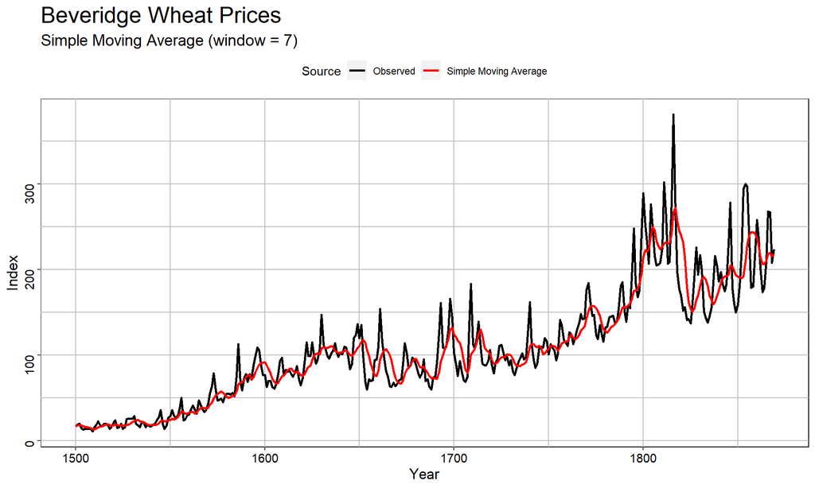

```r
wheat_index_sma <- RtsaPkg::graph_ma(
  wheat_index_dt,
  time_col = "DateTime",
  value_col = "PriceIdx",
  title = "Beveridge Wheat Prices",
  subtitle = "Simple Moving Average (window = 7)",
  window_n = 7,
  x_axis_title = "Year",
  y_axis_title = "Index",
  show_pts = FALSE,
  palette_colors = c("black","red"))
```

4. Call `RtsaPkg::graph_ma()`to define a weighted moving average plot:

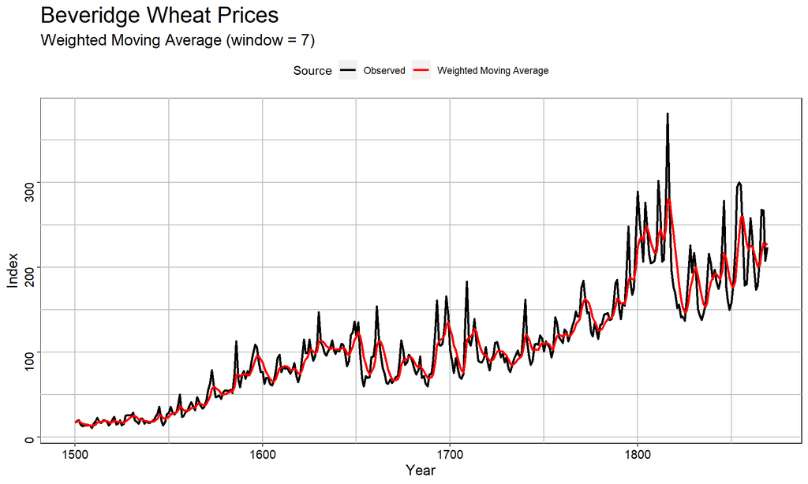

```r
wheat_index_weighted <- RtsaPkg::graph_ma(
  df = wheat_index_dt,
  time_col = "DateTime",
  value_col = "PriceIdx",
  ma_type = "wma",
  window_n = 7,
  title = "Beveridge Wheat Prices",
  subtitle = "Weighted Moving Average (window = 7)",
  x_axis_title = "Year",
  y_axis_title = "Index",
  show_pts = FALSE,
  palette_colors = c("black","red")
)
```

5. Combine the plots *wheat_index_plot*, *wheat_index_sma*, *wheat_index_weighted* into a single plot:

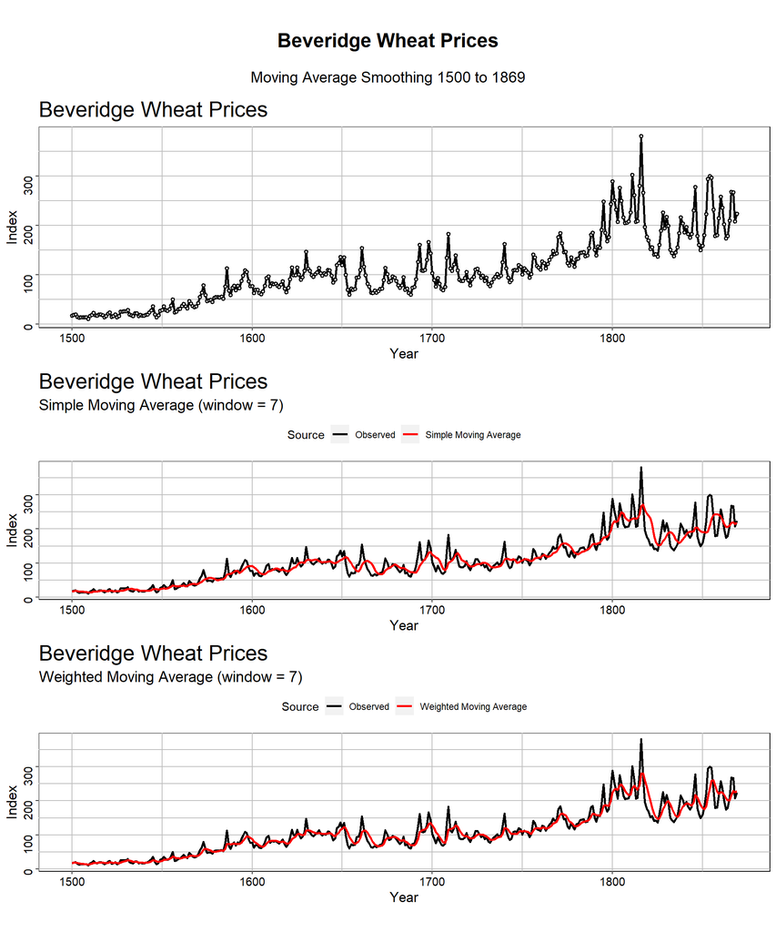

```r
layout <- list(
  plots = list(wheat_index_plot, wheat_index_sma$plots, wheat_index_weighted$plots),
  rows = c(1,2,3),
  cols = c(1,1,1)
)
multi_plot <- RplotterPkg::multi_panel_grid(
  layout = layout,
  col_widths = 10,
  row_heights = c(3.5,3.5,3.5),
  title = "Beveridge Wheat Prices",
  subtitle = "Moving Average Smoothing 1500 to 1869"
)
```

## 2.6 Series that contain a trend and seasonal variation

Task: Decompose the quarterly domestic sales of Australian wine time series into seasonal, trend, and irregular components by calling `RtsaPkg::graph_decompose()`.

1. Read in the data:

```r
apath <- file.path(current_dir, "data", "aus_wine_sales.csv")
wine_sales_dt <- data.table::fread(apath)
str(wine_sales_dt)
```

```
## Classes 'data.table' and 'data.frame':   118 obs. of  2 variables:
##  $ V1: chr  "Mar-1985" "Jun-1985" "Sep-1985" "Dec-1985" ...
##  $ V2: int  7006 10516 11089 9637 6448 9642 11593 9426 5826 9398 ...
##  - attr(*, ".internal.selfref")=<externalptr>
```

2. Rename the variables:

```r
wine_sales_dt <- wine_sales_dt[, .(DateChr = V1, Sales = V2)]
str(wine_sales_dt)
```

```
## Classes 'data.table' and 'data.frame':   118 obs. of  2 variables:
##  $ DateChr: chr  "Mar-1985" "Jun-1985" "Sep-1985" "Dec-1985" ...
##  $ Sales  : int  7006 10516 11089 9637 6448 9642 11593 9426 5826 9398 ...
##  - attr(*, ".internal.selfref")=<externalptr>
```

3. Add a `Date` type column:

```r
wine_sales_dt[, Date_alt := paste(substring(DateChr, 5, 8), substring(DateChr, 1, 3), "01", sep = "-")]
wine_sales_dt[, Date_alt := as.Date(Date_alt, format = "%Y-%b-%d")]
str(wine_sales_dt)
```

```
## Classes 'data.table' and 'data.frame':   118 obs. of  3 variables:
##  $ DateChr : chr  "Mar-1985" "Jun-1985" "Sep-1985" "Dec-1985" ...
##  $ Sales   : int  7006 10516 11089 9637 6448 9642 11593 9426 5826 9398 ...
##  $ Date_alt: Date, format: "1985-03-01" "1985-06-01" ...
##  - attr(*, ".internal.selfref")=<externalptr>
```

4. Convert `wine_sales_dt` to a time series object:

```r
wine_sales_ts <- ts(data = wine_sales_dt$Sales, frequency = 4, start = c(1985, 2))
str(wine_sales_ts)
```

```
##  Time-Series [1:118] from 1985 to 2014: 7006 10516 11089 9637 6448 9642 11593 9426 5826 9398 ...
```

5. Call `RtsaPkg::graph_decompose()` and return both the original, seasonal, trend, random values and their associated plots:

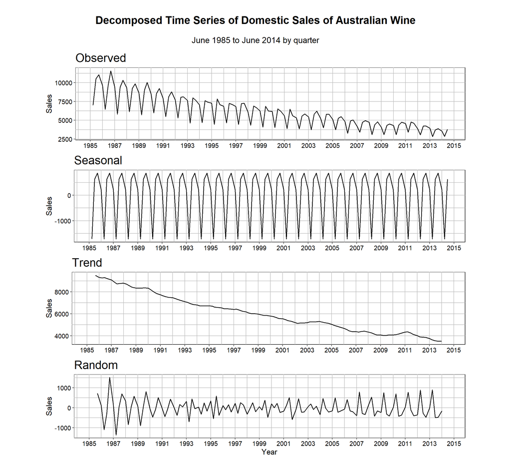

```r
wine_sales_decomposed <- RtsaPkg::graph_decompose(
    series_ts = wine_sales_ts,
    title = "Decomposed Time Series of Domestic Sales of Australian Wine",
    subtitle = "June 1985 to June 2014 by quarter",
    x_title = "Year",
    y_title = "Sales",
    x_major_date_breaks = "2 year",
    x_date_labels = "%Y"
)
```

## 2.7 Autocorrelation and the Correlogram

### 2.7.2 Interpreting the correlogram

Task: Create a random series and plot both the series and its correlogram using `RtsaPkg::graph_acf()`.

1. Create a series data frame from a random normal distribution and plot the autocorrelation (ACF) and partial autocorrelation (PACF):

```r
set.seed(1)
random_df <- data.frame (
  time = seq(1:400),
  value = rnorm(400)
)
```

2. Create the plot:

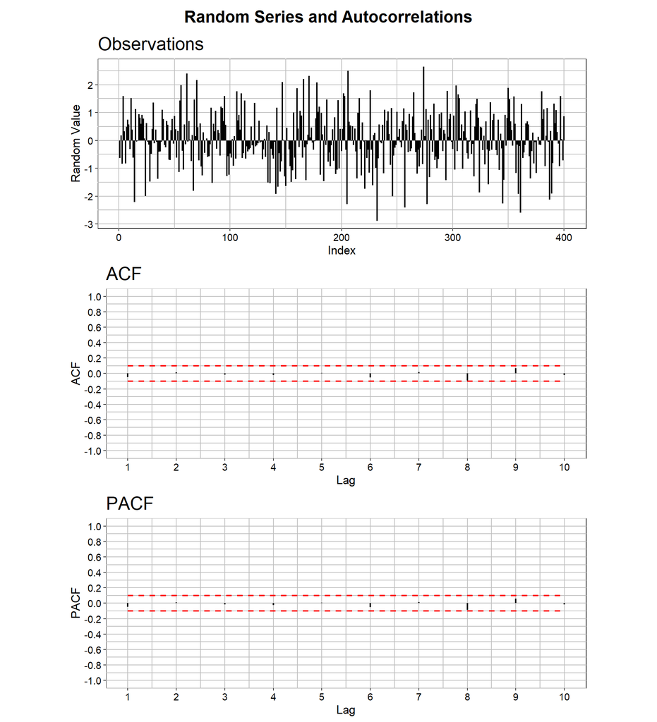

```r
acf_random <- RtsaPkg::graph_acf(
  df = random_df,
  time_col = "time",
  value_col = "value",
  title = "Random Series and Autocorrelations",
  x_title = "Index",
  y_title = "Random Value",
  confid_level = 1.96,
  row_height = 3.5
)
```

The acf’s hover around zero and don’t pass the 95% confidence level.

Task: Plot the autocorrelation from a series that has a trend and is non-stationary.

1. Create the non-stationary series:

```r
set.seed(1)
# set up the plot dataframe
nonstat_df <- data.frame(
  time = seq(1:400),
  value = cumsum(rnorm(400))
)
```

2. Plot the trending non-stationary series:

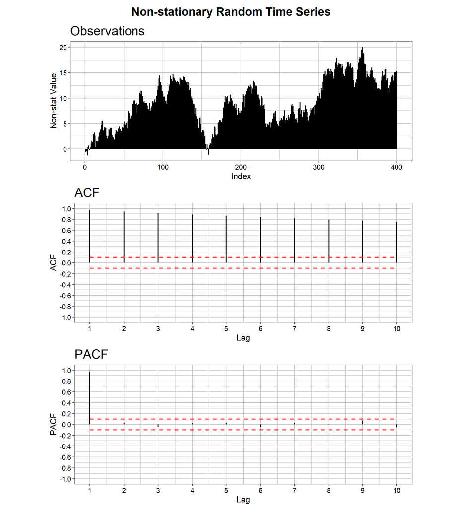

```r
acf_nonstat <- RtsaPkg::graph_acf(
  df = nonstat_df,
  time_col = "time",
  value_col = "value",
  title = "Non-stationary Random Time Series",
  x_title = "Index",
  y_title = "Non-stat Value",
  confid_level = 1.96,
  row_height = 3.5
)
```

Appears that the lag at 1 is significant.

Task: Plot the autocorrelation of monthly observations on air temperaature in Anchorage, Alaska.

1. Read the csv file:

```r
apath <- file.path(current_dir, "data", "alaska_temp_1951-2016.csv")
alaska_temps_dt <- data.table::fread(apath)
str(alaska_temps_dt)
```

```
## Classes 'data.table' and 'data.frame':   792 obs. of  2 variables:
##  $ Date   : int  195101 195102 195103 195104 195105 195106 195107 195108 195109 195110 ...
##  $ Celsius: num  -21.7 -16.6 -16.8 -3 4.3 9.3 11.8 10.3 5.1 -4.4 ...
##  - attr(*, ".internal.selfref")=<externalptr>
```

2. Convert the `Date` variable to a Date variable:

```r
alaska_temps_dt[, Date_alt := paste(substring(as.character(Date), 1, 4), substring(as.character(Date), 5, 6), "01", sep = "-")]
alaska_temps_dt[, Date_alt := as.Date(Date_alt)]
str(alaska_temps_dt)
```

```
## Classes 'data.table' and 'data.frame':   792 obs. of  3 variables:
##  $ Date    : int  195101 195102 195103 195104 195105 195106 195107 195108 195109 195110 ...
##  $ Celsius : num  -21.7 -16.6 -16.8 -3 4.3 9.3 11.8 10.3 5.1 -4.4 ...
##  $ Date_alt: Date, format: "1951-01-01" "1951-02-01" ...
##  - attr(*, ".internal.selfref")=<externalptr>
```

3. Plot the autocorrelation:

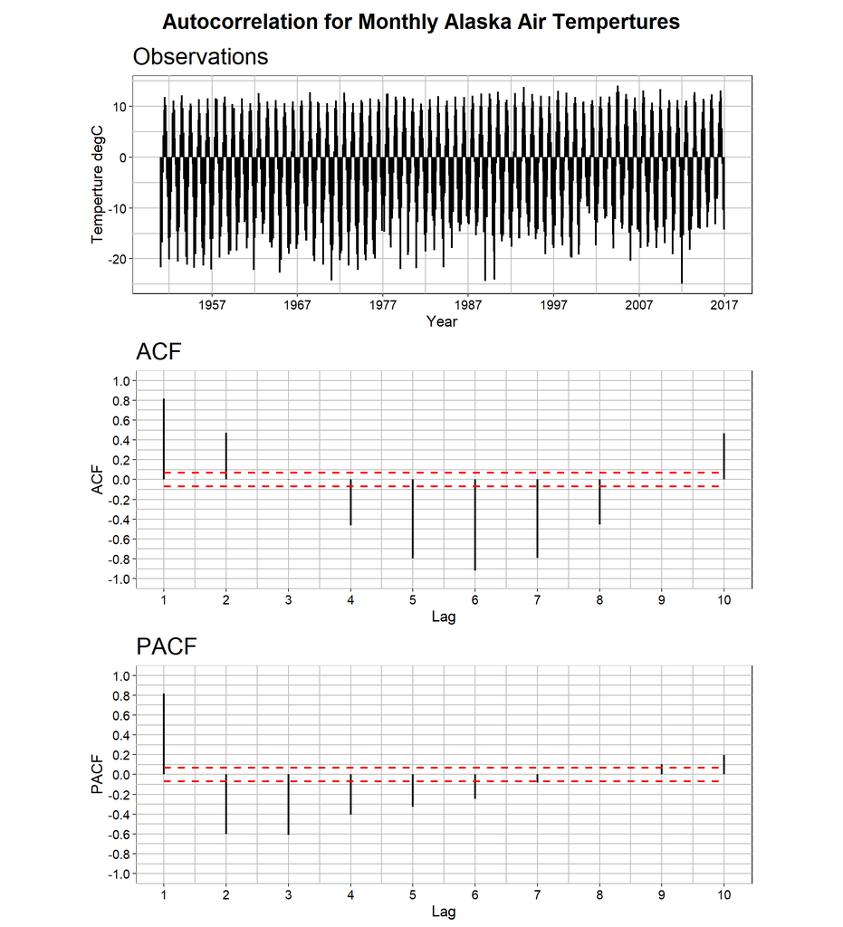

```r
acf_alaska <- RtsaPkg::graph_acf(
  df = alaska_temps_dt,
  time_col = "Date_alt",
  value_col = "Celsius",
  title = "Autocorrelation for Monthly Alaska Air Tempertures",
  x_title = "Year",
  y_title = "Temperture degC",
  obs_x_major_date_breaks = "10 year",
  obs_x_date_labels = "%Y",
  confid_level = 1.96,
  row_height = 3.5
)
```